# 03 - Linear Regression

Biostatistics 735/794 — Machine Learning in Public Health (R)

Alexander McLain

September 05, 2025

**Loading in packages**

```r
library(tidyverse)
library(printr)
library(knitr)
library(kableExtra)

# modeling & selection
library(leaps)
library(MASS)
library(lars)
library(rsample)     # vfold_cv, analysis()/assessment()
library(yardstick)   # rmse

# diagnostics
library(broom)     # augment for residuals, leverage, cooks distance
library(lmtest)    # bptest for heteroscedasticity
library(car)       # vif, component+residual plots
```

**Reading in the Data**

This example uses the **body fat** data from the textbook. Here’s a link to some info about it [here](https://rstudio-pubs-static.s3.amazonaws.com/65314_c0d1e5696cdd4e93a3784ea67f9e3d34.html). We’ll import and briefly inspect.

```r
bf_dat <- read.csv("bodyfat2.csv")
bf_df  <- as.data.frame(bf_dat)

head(bf_df)
```

| density | bodyfat | age | weight | height | neck | chest | abdomen | hip | thigh | knee | ankle | biceps | forearm | wrist |
| --- | --- | --- | --- | --- | --- | --- | --- | --- | --- | --- | --- | --- | --- | --- |
| 1.0708 | 12.3 | 23 | 154.25 | 67.75 | 36.2 | 93.1 | 85.2 | 94.5 | 59.0 | 37.3 | 21.9 | 32.0 | 27.4 | 17.1 |
| 1.0853 | 6.1 | 22 | 173.25 | 72.25 | 38.5 | 93.6 | 83.0 | 98.7 | 58.7 | 37.3 | 23.4 | 30.5 | 28.9 | 18.2 |
| 1.0414 | 25.3 | 22 | 154.00 | 66.25 | 34.0 | 95.8 | 87.9 | 99.2 | 59.6 | 38.9 | 24.0 | 28.8 | 25.2 | 16.6 |
| 1.0751 | 10.4 | 26 | 184.75 | 72.25 | 37.4 | 101.8 | 86.4 | 101.2 | 60.1 | 37.3 | 22.8 | 32.4 | 29.4 | 18.2 |
| 1.0340 | 28.7 | 24 | 184.25 | 71.25 | 34.4 | 97.3 | 100.0 | 101.9 | 63.2 | 42.2 | 24.0 | 32.2 | 27.7 | 17.7 |
| 1.0502 | 20.9 | 24 | 210.25 | 74.75 | 39.0 | 104.5 | 94.4 | 107.8 | 66.0 | 42.0 | 25.6 | 35.7 | 30.6 | 18.8 |

```r
bf_df <- bf_df[ , -1]   # remove density since it is equivalent to bodyfat
glimpse(bf_df)
```

```
## Rows: 252
## Columns: 14
## $ bodyfat <dbl> 12.3, 6.1, 25.3, 10.4, 28.7, 20.9, 19.2, 12.4, 4.1, 11.7, 7.1,…
## $ age     <int> 23, 22, 22, 26, 24, 24, 26, 25, 25, 23, 26, 27, 32, 30, 35, 35…
## $ weight  <dbl> 154.25, 173.25, 154.00, 184.75, 184.25, 210.25, 181.00, 176.00…
## $ height  <dbl> 67.75, 72.25, 66.25, 72.25, 71.25, 74.75, 69.75, 72.50, 74.00,…
## $ neck    <dbl> 36.2, 38.5, 34.0, 37.4, 34.4, 39.0, 36.4, 37.8, 38.1, 42.1, 38…
## $ chest   <dbl> 93.1, 93.6, 95.8, 101.8, 97.3, 104.5, 105.1, 99.6, 100.9, 99.6…
## $ abdomen <dbl> 85.2, 83.0, 87.9, 86.4, 100.0, 94.4, 90.7, 88.5, 82.5, 88.6, 8…
## $ hip     <dbl> 94.5, 98.7, 99.2, 101.2, 101.9, 107.8, 100.3, 97.1, 99.9, 104.…
## $ thigh   <dbl> 59.0, 58.7, 59.6, 60.1, 63.2, 66.0, 58.4, 60.0, 62.9, 63.1, 59…
## $ knee    <dbl> 37.3, 37.3, 38.9, 37.3, 42.2, 42.0, 38.3, 39.4, 38.3, 41.7, 39…
## $ ankle   <dbl> 21.9, 23.4, 24.0, 22.8, 24.0, 25.6, 22.9, 23.2, 23.8, 25.0, 25…
## $ biceps  <dbl> 32.0, 30.5, 28.8, 32.4, 32.2, 35.7, 31.9, 30.5, 35.9, 35.6, 32…
## $ forearm <dbl> 27.4, 28.9, 25.2, 29.4, 27.7, 30.6, 27.8, 29.0, 31.1, 30.0, 29…
## $ wrist   <dbl> 17.1, 18.2, 16.6, 18.2, 17.7, 18.8, 17.7, 18.8, 18.2, 19.2, 18…
```

# Stratified CV and Group-wise CV Error

## Stratified K-fold Cross-Validation

The following example shows:

1. standard K-fold CV,
2. **stratified** K-fold CV for a **continuous** outcome by binning `bodyfat` into quantiles, and
3. compares fold balance and RMSE.

For illustration, we’ll use a **simple linear model**:

$$\text{bodyfat} \sim \text{weight} + \text{abdomen} + \text{forearm} +
\text{wrist}$$

```r
form <- bodyfat ~ weight + abdomen + forearm + wrist
```

Here, our goal will be to use CV to estimate the prediction error of this model. Since we’re not comparing multiple models, the CV estimate of error is not biased.

### Standard vs. Stratified K-fold CV

For **classification**, stratification preserves class proportions per fold.

For a **continuous** outcome, a common approach is to **bin** the outcome (e.g., quintiles) and stratify on those bins so each fold covers the full outcome range.

### Create stratification bins (quintiles of bodyfat)

```r
bf <- bf_df %>%
  mutate(bodyfat_q = ntile(bodyfat, 5) |> factor())  # 5 strata by outcome level
count(bf, bodyfat_q)
```

| bodyfat_q | n |
| --- | --- |
| 1 | 51 |
| 2 | 51 |
| 3 | 50 |
| 4 | 50 |
| 5 | 50 |

### Make folds

```r
K <- 20

# (A) Standard K-fold (no stratification)
folds_std <- vfold_cv(bf, v = K)

# (B) Stratified K-fold (by bodyfat quintile)
folds_strat <- vfold_cv(bf, v = K, strata = bodyfat_q)
```

### Check outcome balance by fold

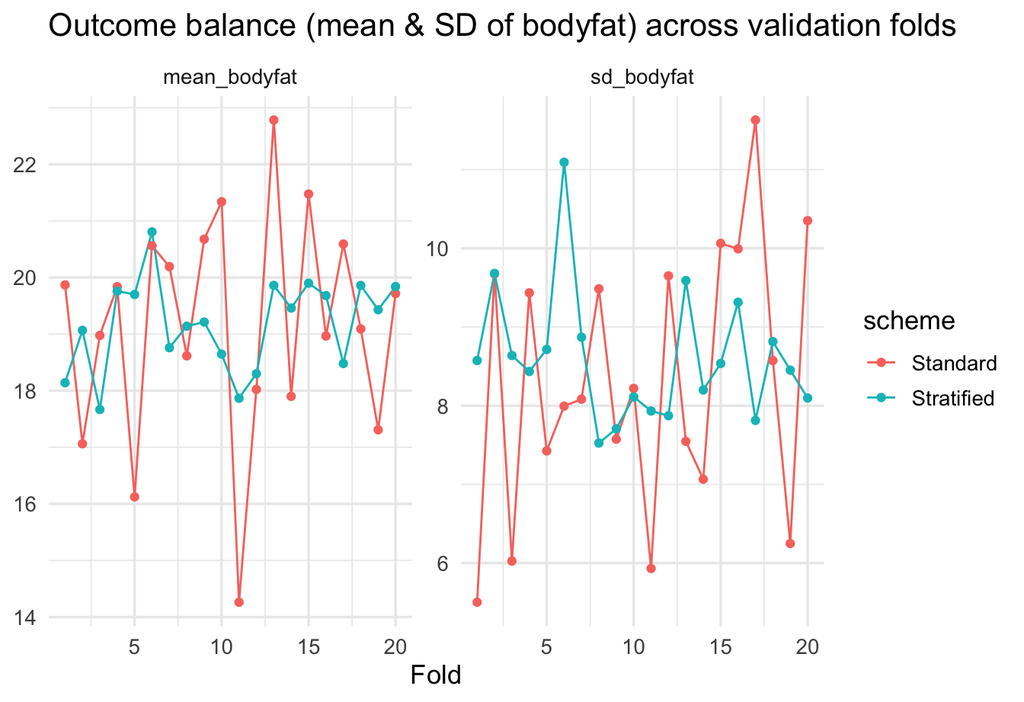

```r
fold_summ <- function(folds, label){
  map_dfr(seq_len(nrow(folds)), function(i){
    va <- assessment(folds$splits[[i]])
    tibble(
      scheme = label,
      fold   = i,
      n      = nrow(va),
      mean_bodyfat = mean(va$bodyfat),
      sd_bodyfat   = sd(va$bodyfat)
    )
  })
}

bal_std   <- fold_summ(folds_std,  "Standard")
bal_strat <- fold_summ(folds_strat,"Stratified")

bind_rows(bal_std, bal_strat) %>%
  pivot_longer(cols = c(mean_bodyfat, sd_bodyfat),
               names_to = "stat", values_to = "value") %>%
  ggplot(aes(x = fold, y = value, group = scheme, color = scheme)) +
  geom_line() + geom_point() +
  facet_wrap(~ stat, scales = "free_y") +
  labs(title = "Outcome balance (mean & SD of bodyfat) across validation folds",
       x = "Fold", y = NULL) +
  theme_minimal(base_size = 13)
```

> Expect the **stratified** scheme to show more uniform `mean_bodyfat` and `sd_bodyfat` across folds.

### CV Workflow & RMSE Comparison

We’ll compute RMSE per validation fold and aggregate.

```r
cv_rmse <- function(folds, formula){
  map_dfr(seq_len(nrow(folds)), function(i){
    sp <- folds$splits[[i]]
    tr <- analysis(sp); va <- assessment(sp)

    fit <- lm(formula, data = tr)
    pred <- predict(fit, newdata = va)
    tibble(fold = i, rmse = rmse_vec(va$bodyfat, pred))
  }) %>%
    summarise(mean_RMSE = mean(rmse), sd_RMSE = sd(rmse), .groups = "drop")
}

res_std   <- cv_rmse(folds_std,   form) %>% mutate(scheme = "Standard")
res_strat <- cv_rmse(folds_strat, form) %>% mutate(scheme = "Stratified")

bind_rows(res_std, res_strat) %>%
  dplyr::select(scheme, mean_RMSE, sd_RMSE) %>%
  kable(digits = 3, caption = "CV RMSE: Standard vs Stratified folds") %>%
  kable_styling(full_width = FALSE)
```

CV RMSE: Standard vs Stratified folds

| scheme | mean_RMSE | sd_RMSE |
| --- | --- | --- |
| Standard | 4.346 | 0.743 |
| Stratified | 4.361 | 0.581 |

To see per-fold variability:

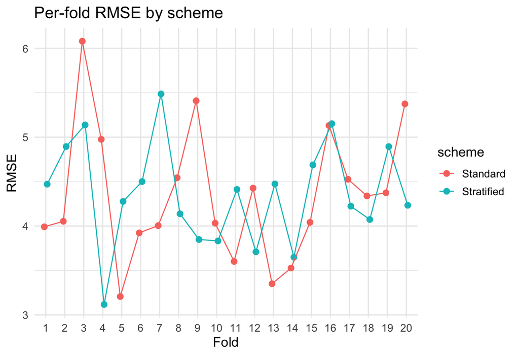

```r
cv_rmse_byfold <- function(folds, formula, label){
  map_dfr(seq_len(nrow(folds)), function(i){
    sp <- folds$splits[[i]]
    tr <- analysis(sp); va <- assessment(sp)
    fit <- lm(formula, data = tr)
    pred <- predict(fit, newdata = va)
    tibble(scheme = label, fold = i, rmse = rmse_vec(va$bodyfat, pred))
  })
}

rmse_std_by   <- cv_rmse_byfold(folds_std,   form, "Standard")
rmse_strat_by <- cv_rmse_byfold(folds_strat, form, "Stratified")

bind_rows(rmse_std_by, rmse_strat_by) %>%
  ggplot(aes(x = factor(fold), y = rmse, color = scheme, group = scheme)) +
  geom_point(position = position_dodge(width = 0.3), size = 2.4) +
  geom_line(position = position_dodge(width = 0.3)) +
  labs(title = "Per-fold RMSE by scheme",
       x = "Fold", y = "RMSE") +
  theme_minimal(base_size = 13)
```

### Notes

- For **continuous** outcomes, “stratified CV” means **binning** the outcome and stratifying on those bins. Here we used **quintiles** via `ntile()`. You can try deciles for larger datasets.
- Stratification tends to **stabilize** fold performance estimates by ensuring each fold contains a comparable range of the outcome.
- Keep **data leakage** in mind: any preprocessing that uses the outcome (e.g., supervised feature selection, target encoding) must be done **inside** each resample split.